# How to Use the CDE Public Schools Directory

5/20/2017

## The Problem

The California Department of Education makes a dataset of public schools available [on their website](http://www.cde.ca.gov/ds/si/ds/pubschls.asp), but the dataset can be a little hard to use. In particular, CDE uses a fourteen digit school ID. This makes it inconvenient to merge with datasets like CASEMIS and SEIS, which use the shorter seven digit school ID.

## The Problem (continued)

The directory of active schools contains over 11,000 schools, so doing this transformation by hand can be time and processor intensive using more conventional tools.

## Proposed Solution

- It efficiently and accurately transforms the fourteen digit school ID code to the more commonly used seven digit ID code
- Since the script reads the data in directly from the CDE website, the script makes it very easy to download and clean a fresh version whenever needed
- The cleaned dataset can be hosted on GitHub for others to use

## Use Cases

Once the dataset is cleaned, it can be used in a variety of ways. Some examples are:

- Using it as a lookup table in Excel or Access to efficiently convert school IDs in datasets like CASEMIS into actual school names
- Building interactive maps to evaluate and plan itinerant service provider caseloads, classrooms, or any system that requires the visualization of school locations

## The Original Dataset

The original dataset has 49 columns. Note the fourteen digit code in the `CDSCode` field.

```
# A tibble: 5 × 49
         CDSCode NCESDist NCESSchool StatusType  County
           <chr>    <chr>      <chr>      <chr>   <chr>
1 01100170000000  0691051       <NA>     Active Alameda
2 01100170109835  0691051      10546     Closed Alameda
3 01100170112607  0691051      10947     Active Alameda
4 01100170118489  0691051      12283     Closed Alameda
5 01100170123968  0691051      12844     Active Alameda
# ... with 44 more variables: District <chr>, School <chr>, Street <chr>,
#   StreetAbr <chr>, City <chr>, Zip <chr>, State <chr>, MailStreet <chr>,
#   MailStrAbr <chr>, MailCity <chr>, MailZip <chr>, MailState <chr>,
#   Phone <chr>, Ext <int>, Website <chr>, OpenDate <date>,
#   ClosedDate <date>, Charter <chr>, CharterNum <chr>, FundingType <chr>,
#   DOC <chr>, DOCType <chr>, SOC <chr>, SOCType <chr>, EdOpsCode <chr>,
#   EdOpsName <chr>, EILCode <chr>, EILName <chr>, GSoffered <chr>,
#   GSserved <chr>, Virtual <chr>, Magnet <chr>, Latitude <dbl>,
#   Longitude <dbl>, AdmFName1 <chr>, AdmLName1 <chr>, AdmEmail1 <chr>,
#   AdmFName2 <chr>, AdmLName2 <chr>, AdmEmail2 <chr>, AdmFName3 <chr>,
#   AdmLName3 <chr>, AdmEmail3 <chr>, LastUpdate <date>
```

## The Cleaned Dataset

```
# A tibble: 5 × 28
         CDSCode Short_CDS NCESDist NCESSchool  County
           <chr>     <chr>    <chr>      <chr>   <chr>
1 01100170000000   0000000  0691051       <NA> Alameda
2 01100170112607   0112607  0691051      10947 Alameda
3 01100170123968   0123968  0691051      12844 Alameda
4 01100170124172   0124172  0691051      12901 Alameda
5 01100170125567   0125567  0691051      13008 Alameda
# ... with 23 more variables: District <chr>, School <chr>,
#   MailStreet <chr>, MailStrAbr <chr>, MailCity <chr>, MailZip <chr>,
#   MailState <chr>, Phone <chr>, Ext <int>, Website <chr>,
#   OpenDate <date>, ClosedDate <date>, Charter <chr>, DOCType <chr>,
#   SOCType <chr>, EdOpsName <chr>, EILName <chr>, GSoffered <chr>,
#   GSserved <chr>, Virtual <chr>, Latitude <dbl>, Longitude <dbl>,
#   LastUpdate <date>
```

## Download the Cleaned Dataset

You can download the cleaned dataset by right clicking and selecting download linked file:

cleaned_cde_schools.csv

## Ways to Use the Data

The following are some examples of how this data can be used.

## Top Ten Biggest Districts

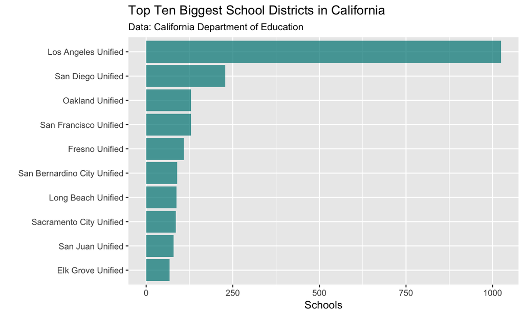

## Top Ten Oldest Schools

Click on the markers for more information.

[interactive chart not shown]

## Service Provider Caseloads

This map uses simulated data. The size of the circle represents the size of the caseload.

[interactive chart not shown]